# share

# 正态分布的条件分布

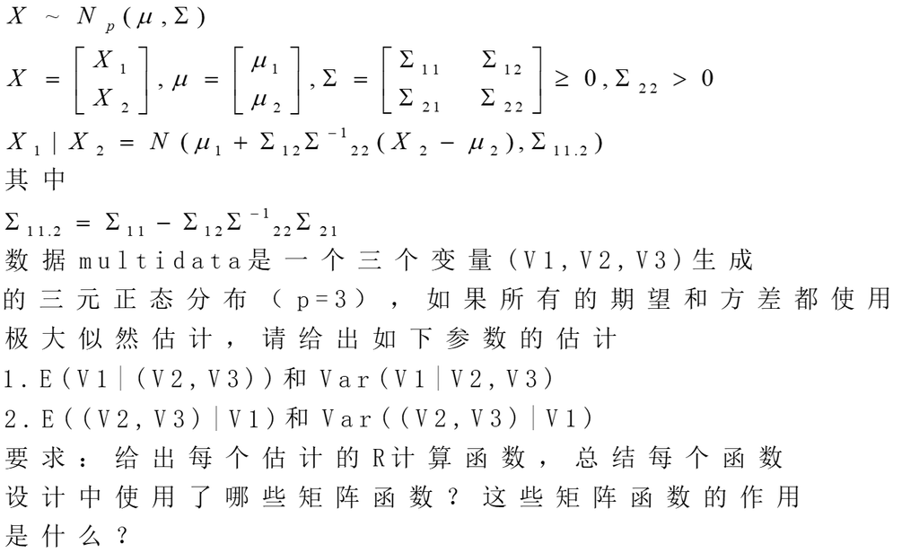

question.

## 数值计算

注意：上述$X_1,X_2$不被限制维度。

根据极大似然，可以计算出来三元正态分布的均值和协方差估计：

$\hat\mu = ({\bar x}_1, {\bar x}_2, {\bar x}_3)$

$\hat{\Sigma} = \frac{1}{N} * \sum\limits_{i=1}^N\{(x^i-\bar{x})(x^i-\bar{x})^T\}$

求解可能需要一些矩阵求导的结论,这里列举一下$\hat \mu$d的求解,网上有很多资源。https://iam8bits.blog.csdn.net/article/details/99753664

设n维相互独立的随机变量x服从多元正态分布$x\sim N_n(\mu ,\sigma^2)$,概率密度函数
$$f(x)=(2\pi)^{-\frac{n}{2}}|\Sigma|^{\frac{1}{2}}exp(-\frac{1}{2}(x-\mu)^T\Sigma^{-1}(x-\mu))$$

其似然函数与对数似然函数是

$$\begin{aligned}
L(\mu,\Sigma)&=\Pi_{i=1}^{m}f(x^{(i)};\mu,\Sigma) \\
&=(2\pi)^{-\frac{nm}{2}}|\Sigma|^{\frac{m}{2}}exp(-\frac{1}{2}\sum_{i=1}^m(x^{(i)}-\mu)^T\Sigma^{-1}(x^{(i)}-\mu)) \\
l(\mu,\Sigma)&=ln(2\pi)^{-\frac{mn}{2}}+ln|\Sigma|^{-\frac{m}{2}}-\frac{1}{2}\sum_{i=1}^m(x^{(i)}-\mu)^T\Sigma^{-1}(x^{(i)}-\mu) \\
&=C-\frac{m}{2}ln|\Sigma|-\frac{1}{2}\sum_{i=1}^m(x^{(i)}-\mu)^T\Sigma^{-1}(x^{(i)}-\mu)
\end{aligned}$$

令偏导数$\frac{\partial l}{\partial \mu}=0,\frac{\partial l}{\partial \Sigma}=0$

$$\begin{aligned}
\because (x-\mu)^T\Sigma^{-1}(x-\mu) &= x^T\Sigma^{-1}x-x^T\Sigma^{-1}\mu-\mu^T\Sigma^{-1}x+\mu^T\Sigma^{-1}\mu\\
&= x^T\Sigma^{-1}x-2x^T\Sigma^{-1}\mu+\mu^T\Sigma^{-1}\mu\\\\
\therefore\frac{\partial l}{\partial \mu}&=\frac{\partial}{\partial \mu}(-\frac{1}{2}\sum_{i=1}^m(x^{(i)}-\mu)^T\Sigma^{-1}(x^{(i)}-\mu)) \\
&=-\frac{1}{2}\frac{\partial}{\partial \mu}(\sum_{i=1}^m x^{(i)^T}\Sigma^{-1}x^{(i)}-2\sum_{i=1}^m x^{(i)^T}\Sigma^{-1}\mu + m\mu^T\Sigma^{-1}\mu) \\
&=\frac{\partial}{\partial \mu}(\sum_{i=1}^m x^{(i)^T}\Sigma^{-1}\mu -\frac{1}{2}m\mu^T\Sigma^{-1}\mu) \\
\end{aligned}$$

根据矩阵求导法则
$$\frac{d(A^TX)}{dX}=A\\
\frac{d(X^TAX)}{dX}=AX+A^TX$$

得到

$$\begin{aligned}
\frac{\partial}{\partial \mu}(\sum_{i=1}^m x^{(i)^T}\Sigma^{-1}\mu-\frac{1}{2}m\mu^T\Sigma^{-1}\mu) &=\sum_{i=1}^m \Sigma^{-1}x^{(i)}-m\Sigma^{-1}\mu \\
&=\Sigma^{-1}\sum_{i=1}^mx^{(i)}-m\Sigma^{-1}\mu=0 \\
\therefore \mu&=\bar x
\end{aligned}$$

```r
data = read.csv('E:\\大三上\\Non-Parametric Statistics 王星\\1125share\\unempstates-30years.csv', header = TRUE)

# 提取数据集中的CA,PA,OR三列做一个multidata
multidata = cbind(matrix(data$CA), matrix(data$PA), matrix(data$OR))
colnames(multidata) = paste0('V', 1:3)

# 先做\mu=(\mu_1,\mu_2,\mu_3)的极大似然估计
mu_mle = apply(multidata, 2, mean); mu_mle
```

```
##       V1       V2       V3
## 7.204087 6.517067 7.171875
```

```r
N = nrow(multidata)

# 三元正态分布协方差矩阵的极大似然估计
sigma_mle = t(multidata[,] - mu_mle) %*% (multidata[,] - mu_mle) / N; sigma_mle
```

```
##          V1       V2       V3
## V1 3.519201 2.549992 2.541452
## V2 2.549992 3.857282 2.996074
## V3 2.541452 2.996074 3.841629
```

求解$E(X_1|(X_2, X_3)), Var(X_1|(X_2, X_3))$

求解$E((X_2, X_3)|X_1), Var((X_2, X_3)|X_1)$

```r
EVar = function(multidata, x1, x2){
  # example1: x1 = c(1,2); x2 = c(3)
  # example2: x1 = c(2), x2 = c(1, 3)

  # 计算三元正态分布的极大似然估计
  mu_mle = apply(multidata, 2, mean); mu_mle
  mu_mle = matrix(mu_mle, ncol = 1) # 做成列向量

  sigma_mle = t(sweep(multidata, 2, mu_mle)) %*% (sweep(multidata, 2, mu_mle)) / nrow(multidata)
  # 可以用没转matrix的mu_mle 直接multidata-mu_mle 快很多
  sigma_mle = matrix(sigma_mle, ncol = 3)

  print('----------sigma_11/12/21/22----------')
  print(sigma_mle)


  # 切分sigma_11 sigma_12 sigma_21 sigma_22
  sigma_11 = sigma_mle[x1, x1];print(sigma_11)
  sigma_12 = matrix(sigma_mle[x1, x2], nrow = length(x1), ncol = length(x2));print(sigma_12)
  sigma_21 = matrix(sigma_mle[x2, x1], nrow = length(x2), ncol = length(x1));print(sigma_21)
  sigma_22 = sigma_mle[x2, x2];print(sigma_22)

  print('----------mu_1 mu_2-----------')

  # 切分mu_1 mu_2
  mu_1 = matrix(mu_mle[x1], ncol = 1); print(mu_1)
  mu_2 = matrix(mu_mle[x2], ncol = 1); print(mu_2)

  # 根据条件期望满足正态分布的公示计算期望
  e_cond = mu_1 + sigma_12 %*% solve(sigma_22) %*% (multidata[sample(1:nrow(multidata), 1), x2] - mu_2)
  # 根据条件期望满足正态分布的公示计算方差
  var_cond = sigma_11 - sigma_12 %*% solve(sigma_22) %*% sigma_21

  print(paste0('系数', sigma_12 %*% solve(sigma_22)))

  return (list(e_cond, var_cond))
}

# V1->x1, (V2, V3)->x2
ans1 = EVar(multidata, c(1), c(2, 3))
```

```
## [1] "----------sigma_11/12/21/22----------"
##          [,1]     [,2]     [,3]
## [1,] 3.354863 2.710579 2.539250
## [2,] 2.710579 3.559156 3.142788
## [3,] 2.539250 3.142788 3.693896
## [1] 3.354863
##          [,1]    [,2]
## [1,] 2.710579 2.53925
##          [,1]
## [1,] 2.710579
## [2,] 2.539250
##          [,1]     [,2]
## [1,] 3.559156 3.142788
## [2,] 3.142788 3.693896
## [1] "----------mu_1 mu_2-----------"
##          [,1]
## [1,] 7.204087
##          [,1]
## [1,] 6.517067
## [2,] 7.171875
## [1] "系数0.621484116158965" "系数0.158655476493204"
```

```r
# (V2, V3)->x1, V1->x2
ans2 = EVar(multidata, c(2, 3), c(1))
```

```
## [1] "----------sigma_11/12/21/22----------"
##          [,1]     [,2]     [,3]
## [1,] 3.354863 2.710579 2.539250
## [2,] 2.710579 3.559156 3.142788
## [3,] 2.539250 3.142788 3.693896
##          [,1]     [,2]
## [1,] 3.559156 3.142788
## [2,] 3.142788 3.693896
##          [,1]
## [1,] 2.710579
## [2,] 2.539250
##          [,1]    [,2]
## [1,] 2.710579 2.53925
## [1] 3.354863
## [1] "----------mu_1 mu_2-----------"
##          [,1]
## [1,] 6.517067
## [2,] 7.171875
##          [,1]
## [1,] 7.204087
## [1] "系数0.807955259298907" "系数0.756886188084005"
```

首先，计算了三元正态分布的期望以及协方差矩阵的极大似然估计，这之中使用到了`apply()`, `t()`等函数，前者对multidata每一列作用，求出$\bar x$。后者在计算协方差矩阵极大似然估计的时候计算了$x^i - \bar x$的转置。另外，矩阵乘法%*%也被使用，目的是计算$x^i - \bar x$和$(x^i - \bar x)^T$的积。

在计算条件方差 $Var(X_1|X_2) = \Sigma_{11} - \Sigma_{12}\Sigma^{-1}_{22}\Sigma_{21}$的时候，也运用到了矩阵转置`t()`, 矩阵求逆`solve()`以及矩阵乘法 `%*%`。

### 答案输出

由于在计算条件期望的时候，还需要输入一个X2的观测值，在上面的函数中，我设置了从multidata中随机抽取一条数据作为X2的输入值，没有安排外部接入。所以下面会直接输出条件期望的结果。

```r
print(paste0("----------第一问----------", ans1))
```

```
## [1] "----------第一问----------10.1294272408998"
## [2] "----------第一问----------1.26741528499556"
```

```r
print(paste0("----------第二问----------", ans2))
```

```
## [1] "----------第二问----------c(5.14024162664184, 5.88207543573858)"
## [2] "----------第二问----------c(1.36912902747086, 1.09118768232432, 1.09118768232431, 1.77197357242731)"
```

### 公示表达

为了方便阅读，用LaTeX重新打一遍计算出来的结果，下面将在X2上留空。
$$E(V_1|(V_2, V_3)) = 7.20 + (0.62 \quad 0.16) * (X2 - \left(
\begin{array} {4}
6.52\\
7.17
\end{array}
\right))$$

$$Var(V_1|(V_2, V_3)) = 1.267$$

$$E((V_2, V_3)|V_1) = \left(
\begin{array} {5}
6.52 \\ 7.17
\end{array}
\right) + \left(
\begin{array} {6}
0.81\\
0.76
\end{array}
\right) * (X1 - 7.20)$$

$$Var((V_2, V_3)|V_1) = \left(
\begin{array} {2}
1.37\quad 1.1 \\
1.1 \quad 1.77
\end{array}
\right)$$

**sweep** and **apply**

```r
# apply对于每一行求中位数 用sweep做减法
t(apply(multidata,1,function(x){x - median(x)}))[21:27,]
```

```
##       V1 V2   V3
## [1,] 0.4  0 -0.8
## [2,] 0.4  0 -1.0
## [3,] 0.3  0 -1.2
## [4,] 0.3  0 -1.3
## [5,] 0.2  0 -1.5
## [6,] 0.4  0 -1.4
## [7,] 0.4  0 -1.3
```

```r
# apply函数有一个问题是会把计算结果按照列摆放,是我哪儿参数的问题么

# apply对于每一列求中位数 用sweep做减法
apply(multidata,2,function(x){x - median(x)})[21:27,]
```

```
##       V1  V2   V3
## [1,] 1.1 1.7  0.2
## [2,] 1.0 1.6 -0.1
## [3,] 0.8 1.5 -0.4
## [4,] 0.7 1.4 -0.6
## [5,] 0.6 1.4 -0.8
## [6,] 0.6 1.2 -0.9
## [7,] 0.5 1.1 -0.9
```

```r
# sweep也可以做
sweep(multidata,1,apply(multidata,1,median))[21:27,]
```

```
##       V1 V2   V3
## [1,] 0.4  0 -0.8
## [2,] 0.4  0 -1.0
## [3,] 0.3  0 -1.2
## [4,] 0.3  0 -1.3
## [5,] 0.2  0 -1.5
## [6,] 0.4  0 -1.4
## [7,] 0.4  0 -1.3
```

```r
sweep(multidata,2,apply(multidata,2,median))[21:27,]
```

```
##       V1  V2   V3
## [1,] 1.1 1.7  0.2
## [2,] 1.0 1.6 -0.1
## [3,] 0.8 1.5 -0.4
## [4,] 0.7 1.4 -0.6
## [5,] 0.6 1.4 -0.8
## [6,] 0.6 1.2 -0.9
## [7,] 0.5 1.1 -0.9
```

## 数据绘图题

几个常用的函数 `geom_segment`(mapping = NULL, data = NULL, …) `geom_text`(mapping = NULL, data = NULL, label = , nudge_x = 0, nudge_y = 0, hjust = 0…) `geom_ribbon`(mapping = NULL, data = NULL, alpha = )

`alpha`透明度;`nudge_x`控制标签的相对左右位置;`nudge_y`控制标签的相对上下位置

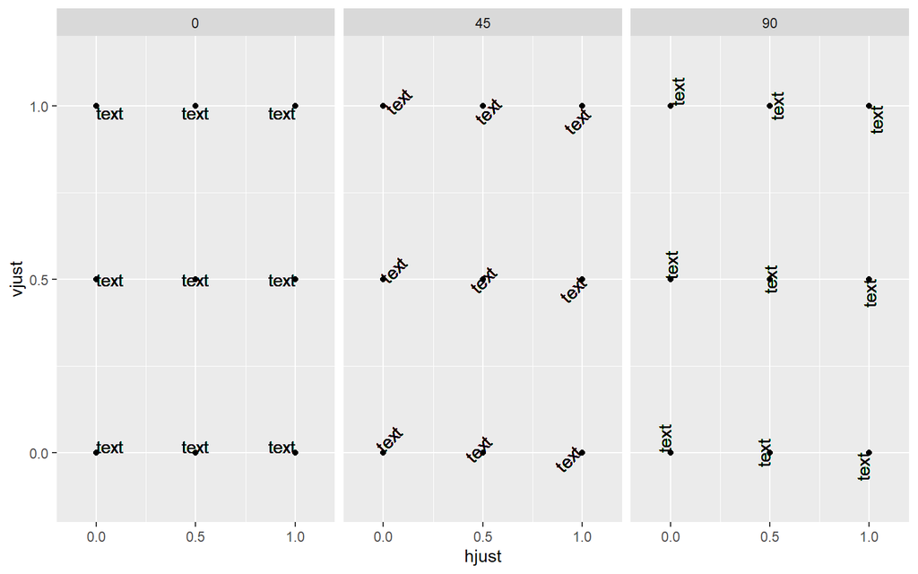

```r
td <- expand.grid(
    hjust=c(0, 0.5, 1),
    vjust=c(0, 0.5, 1),
    angle=c(0, 45, 90),
    nudge_x=c(0, 0.5, 1),
    nudge_y=c(0, 0.5, 1),
    text="text"
)

# hjust、vjust：文本的水平和垂直调整距离，取值范围是0-1，0代表right/bottom，1代表left/top。
ggplot(td, aes(x=hjust, y=vjust)) +
    geom_point() +
    geom_text(aes(label=text, angle=angle, hjust=hjust, vjust=vjust)) +
    facet_grid(~angle) + # 按照角度分面
    scale_x_continuous(breaks=c(0, 0.5, 1), expand=c(0, 0.2)) +
    scale_y_continuous(breaks=c(0, 0.5, 1), expand=c(0, 0.2))
```

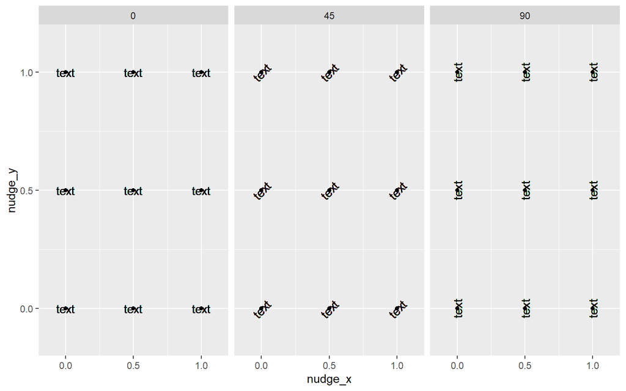

```r
ggplot(td, aes(x=nudge_x, y=nudge_y)) +
    geom_point() +
    geom_text(aes(label=text, angle=angle, nudge_x=nudge_x, nudge_y=nudge_y)) +
    facet_grid(~angle) + # 按照角度分面
    scale_x_continuous(breaks=c(0, 0.5, 1), expand=c(0, 0.2)) +
    scale_y_continuous(breaks=c(0, 0.5, 1), expand=c(0, 0.2))
```

`text`(x, y, labels,) 坐标取图上的数值即可 `segments`(x0, y0, x1=x0, y1=y0, …) 从(x0,y0)画到(x1,y1)

### 子题一

50个洲的各月份平均失业率提取出来，按月绘制曲线图，分析失业率的变点年份，进行标注（或输出累积平均失业率2D变化曲线图）

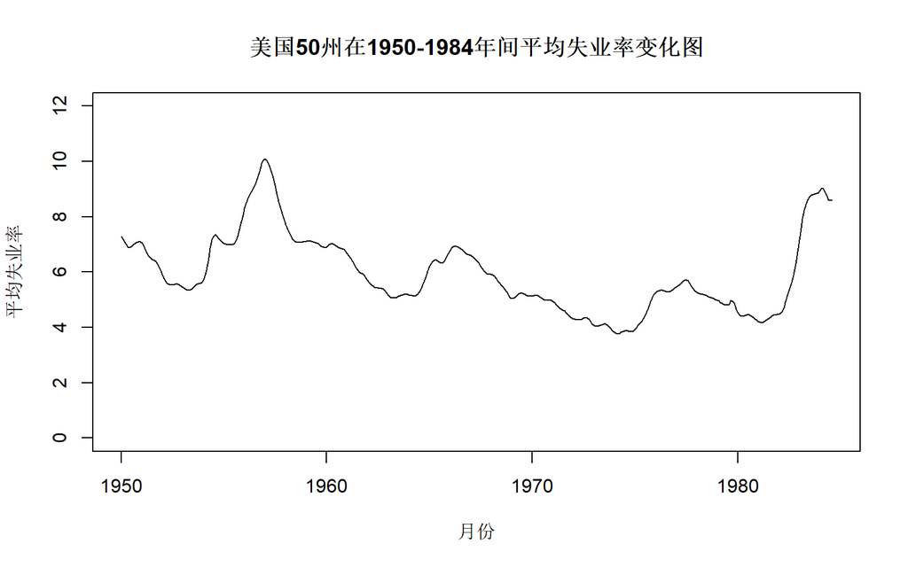

```r
# 日期转换方法 dmy(paste0("01 ", gsub("-", " 19", data$Month)))

# 每月均值
aver_permon = apply(data[,2:51], 1, mean)

plot(dmy(paste0("01 ", gsub("-", " 19", data$Month))), aver_permon,
     type = 'l', xlab = '月份', ylab = "平均失业率", ylim = c(0, 12),
     main = '美国50州在1950-1984年间平均失业率变化图')
```

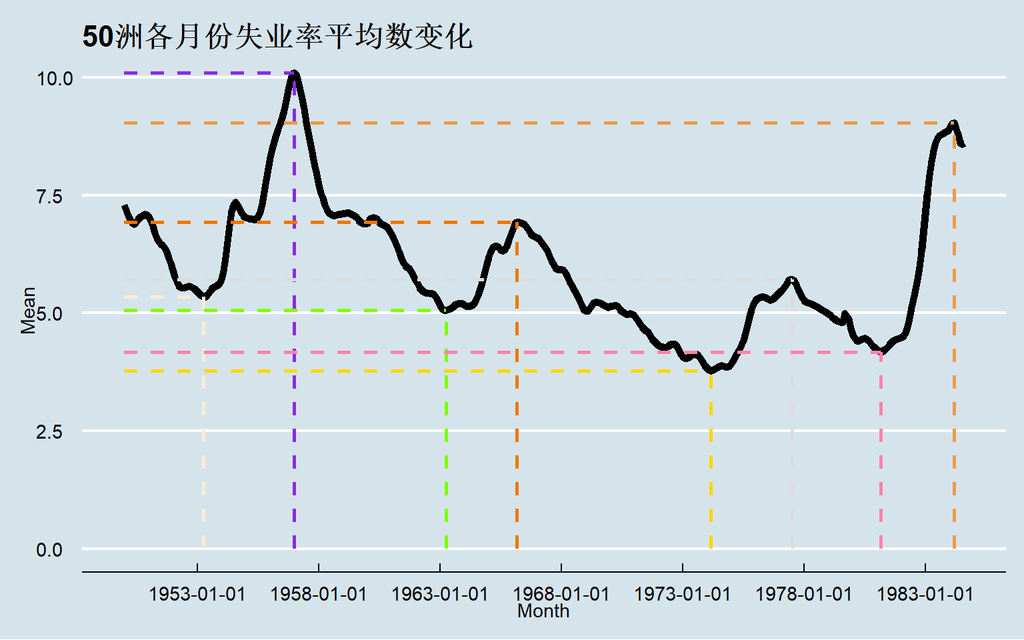

```r
# 目测标注转折点
turning_points = as.Date(c("1953-04-01", "1957-01-01", "1963-04-01", "1966-03-01", "1974-03-01", "1977-07-01", "1981-03-01", "1984-03-01"))
turning_rates = c(5.344,10.096,5.056,6.926,3.774,5.718,4.174,9.030)

temp = data.frame(Month = dmy(paste0("01 ", gsub("-", " 19", data$Month))), Mean = aver_permon)

loc = data.frame(x = as.Date(rep('1950-01-01', 8)), y = rep(0, 8), tp = turning_points, tr = turning_rates)

ggplot(temp, aes(x = Month, y = Mean))+
  geom_line(lwd = 2)+
  labs(x="Month",y="Mean", title = "50洲各月份失业率平均数变化") +
  scale_x_date(date_break= "5 year") +
  geom_segment(aes(x = tp, y = y, xend = tp, yend = tr),
               data= loc,
               lty = 2,
               lwd = 1,
               colour = c("antiquewhite","blueviolet","chartreuse","darkorange2","gold","gainsboro","palevioletred1","tan2")) +
  geom_segment(aes(x = x, y = tr, xend = tp, yend = tr),
               data= loc,
               lty = 2,
               lwd = 1,
               colour = c("antiquewhite","blueviolet","chartreuse","darkorange2","gold","gainsboro","palevioletred1","tan2")) +
  theme_economist()
```

### 子题二

将失业率的平均值和标准差放在一张图上，并将50个洲的失业率数据作为背景，加注legend，给出从图上观察到的分析结果。

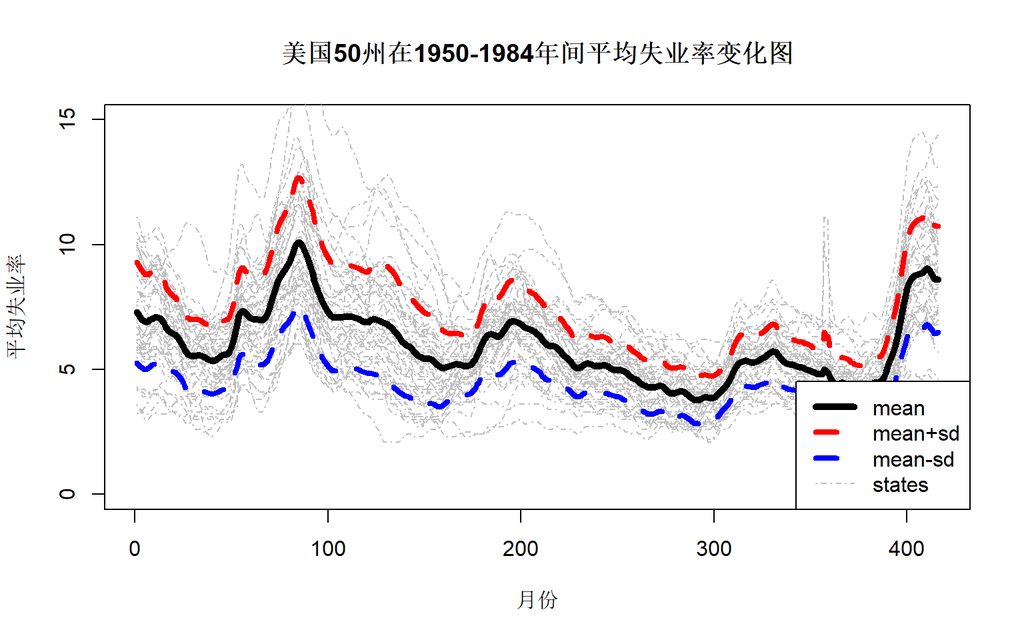

```r
# 每个月的标准差
sd_permon = apply(data[, 2:51], 1, sd)
plus_sd = aver_permon + sd_permon
minus_sd = aver_permon - sd_permon

plot(1:length(aver_permon), aver_permon, type = 'l', xlab = '月份', ylab = "平均失业率", main = '美国50州在1950-1984年间平均失业率变化图', xlim = c(1,416), ylim = c(0,15), col = 'black', lwd = 5)

for(state_no in 2:51){
  lines(data[, state_no], lty = 4, col = 'grey')
}

# 加上均值线段以及上下一个标准差的
lines(plus_sd, lty = 2, col = 'red', lwd = 4)
lines(minus_sd, lty = 2, col = 'blue', lwd = 4)
lines(aver_permon, lty = 1, lwd = 5)

legend("bottomright", legend = c('mean', 'mean+sd', 'mean-sd', 'states'), lty = c(1, 2, 2, 4), col = c('black', 'red', 'blue', 'grey'), lwd = c(5, 4, 4, 1))
```

当然，用ggplot会更加方便一些

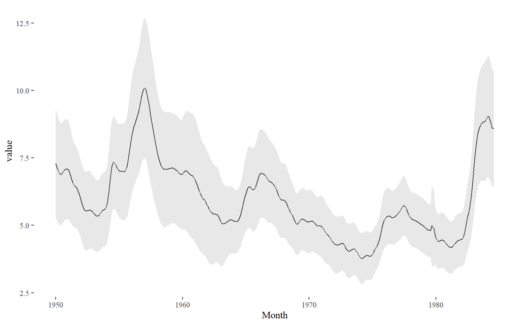

```r
dat = data.frame(dmy(paste0("01 ", gsub("-", " 19", data$Month))), aver_permon)
colnames(dat) = c("Month", "value")

ggplot(dat, aes(x=Month,y=value))+
  geom_line()+
  geom_ribbon(aes(ymax = value + sd_permon,
                  ymin = value - sd_permon),
                  alpha = 0.3,
                  fill = "grey70",
                  colour = NA )+
  theme_tufte()
```

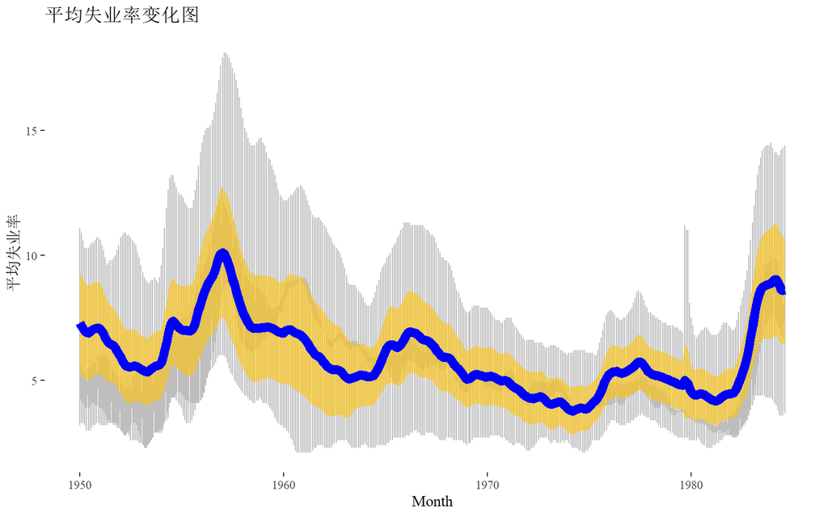

```r
adj_data = data.frame(dmy(paste0("01 ", gsub("-", " 19", data$Month))), data[, 2:51])
colnames(adj_data)[1] = "Month"
adj_data = melt(adj_data, id.vars="Month")

ggplot(adj_data, aes(x = Month, y = value)) +
  geom_line(lty = 1, col = 'grey') +
  geom_ribbon(aes(ymax = aver_permon + sd_permon,
                  ymin = aver_permon - sd_permon),
                  data = dat,
                  alpha = 0.6, # 透明度
                  fill = "#FFC408",
                  colour = NA )+
  geom_line(data = dat, lwd = 3, lty = 1, col = 'blue')+
  labs(x = 'Month', y = '平均失业率', title = '平均失业率变化图')+
  theme_tufte()
```

其中，蓝色线标注了平均失业率，黄色区域是$mean \pm std$，灰色区域则是五十个州的数据所占范围。

从以上这些图像中我们发现 * 失业率升降成周期性变化，周期为十年左右。 * 大部分洲的失业率都在50洲均值的一倍标准差之内。 * 失业率越高，各洲失业率的方差就越大。

# 绘图思考

## The histogram of normalized std

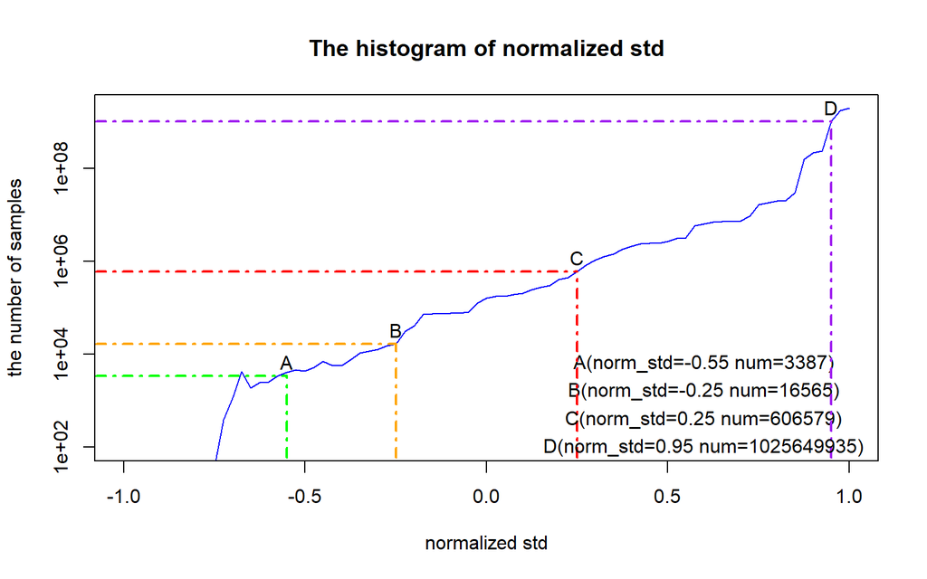

```r
set.seed(824)
std_list = seq(-0.75, 1.00, 0.025)
number_list = sort(rnorm(71, 5, 2))
# 调整一下来模拟图上的数据
adjust_list = 10^number_list + rexp(71, 0.001)


ShowPoint = function(x, col_, labels_, lx, ly, data){
  # base包我不知道用segments或者text是否可以批量添加,geom_text geom_segments可以
  # 从x的值反推回去x在data里面的下标,这是很不智能的,应该开一个搜索。但这里简单就这么凑合了。
  index = (x + 0.75) / 0.025 + 1

  # 竖直线段
  segments(x, 10, x, data[index],
           col = col_, lty = 4, lwd = 2)

  # 横线段  为什么是-1.25...试出来的让画的还看得凑合
  segments(-1.25, data[index], x, data[index],
           col = col_, lty = 4, lwd = 2)

  # 加字母标记
  text(x, data[index]*2, labels = labels_)

  # 加右下角注释
  text(lx, ly, paste0(labels_,"(norm_std=",as.character(x)," num=",as.character(as.integer(adjust_list[index])),")"))
}

plot(std_list, adjust_list, col = 'blue', type = 'l',
     xlim = c(-1,1), ylim = c(100, max(adjust_list)), log='y', #对数坐标轴变换,1e-2 1e-4 1e-6 1e-8才会等距
     xlab = 'normalized std', ylab = 'the number of samples', main = 'The histogram of normalized std')

ShowPoint(-0.55, "green", "A", 0.6, 6400, adjust_list)
ShowPoint(-0.25, "orange", "B", 0.6, 1600, adjust_list)
ShowPoint(0.25, "red", "C", 0.6, 400, adjust_list)
ShowPoint(0.95, "purple", "D", 0.6, 100, adjust_list)
```

## 2D histogram of normalized std and loss

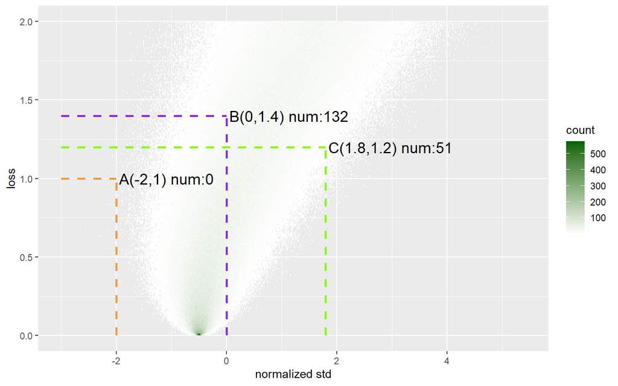

```r
y = runif(10^6,0,2)
x = rep(0, 10^6)
for(i in 1:10^6)
  x[i] = rnorm(1, 1 - cos(0 - y[i]) * 1.5, sqrt(y[i]/3))

# 生成数据框
data <- data.frame(x, y)

# 需要标点的坐标
loc = data.frame(tp = c(-2, 0, 1.8), tr = c(1, 1.4, 1.2))

ggplot(data, aes(x = x, y = y)) +
  geom_bin2d(binwidth = 0.01) +
  scale_fill_gradient2(low="blue", high = "darkgreen") +
  geom_segment(aes(x = tp, y = rep(0,3), xend = tp, yend = tr),
               data= loc,
               lty = 2,
               lwd = 1,
               colour = c("tan2","blueviolet","chartreuse")) +
  geom_segment(aes(x = rep(-3, 3), y = tr, xend = tp, yend = tr),
               data= loc,
               lty = 2,
               lwd = 1,
               colour = c("tan2","blueviolet","chartreuse")) +
  geom_text(aes(x = tp, y = tr),
            data = loc,
            label = c("A(-2,1) num:0","B(0,1.4) num:132","C(1.8,1.2) num:51"),
            size = 5,
            hjust = 0, nudge_x = 0.05) +
  labs(x = 'normalized std', y = 'loss') +
  theme_grey()
```

## Perceived Age v.s. Real Age

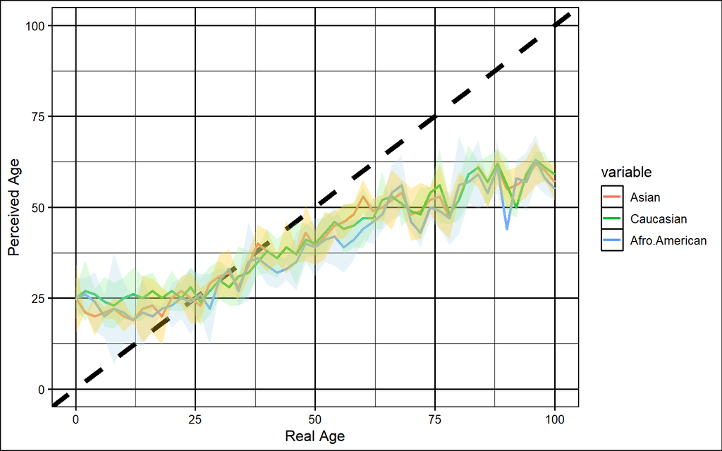

```r
real_age = seq(0, 100, 2)
perceived_age_asian =
  c(25, 21, 20, 21, 22, 20, 19, 22, 23, 20, 25, 27, 25, 23, 29, 31, 32, 28, 34, 40, 38, 36, 39, 37, 43, 39, 42, 45, 46, 48, 53, 49, 50, 52, 54, 48, 49, 52, 53, 47, 56, 57, 59, 54, 61, 55, 56, 58, 62, 60, 57)
perceived_age_caucasian =
  c(25, 27, 26, 24, 23, 25, 26, 25, 27, 25, 27, 25, 28, 24, 27, 30, 28, 31, 32, 35, 38, 36, 39, 37, 41, 40, 43, 46, 44, 45, 47, 47, 52, 53, 51, 49, 48, 54, 56, 48, 52, 59, 61, 57, 62, 56, 50, 59, 63, 61, 59)
perceived_age_afro =
  c(25, 26, 24, 20, 22, 21, 19, 21, 20, 22, 23, 25, 24, 26, 22, 30, 33, 27, 35, 36, 34, 32, 33, 35, 40, 39, 41, 42, 39, 41, 44, 46, 48, 54, 56, 46, 43, 50, 49, 47, 56, 57, 59, 54, 61, 44, 58, 57, 63, 58, 55)
ground_truth = seq(0, 100, 2)

noise1 = data.frame(real_age, "value" = perceived_age_asian, "noise" = rnorm(length(perceived_age_asian), 5.0, 2.7))
noise2 = data.frame(real_age, "value" = perceived_age_caucasian, "noise" = rnorm(length(perceived_age_caucasian), 5.3, 2.6))
noise3 = data.frame(real_age, "value" = perceived_age_afro, "noise" = rnorm(length(perceived_age_afro), 5.2, 2.8))

mws = data.frame(real_age, "Asian" = perceived_age_asian, "Caucasian" = perceived_age_caucasian, "Afro-American" = perceived_age_afro)


# reshape2的宽表->长表
mws = melt(mws, id.vars="real_age")


ggplot(mws, aes(x = real_age, y = value, colour = variable)) +
  geom_abline(slope = 1, intercept = 0, lty = 2, lwd = 2) +
  geom_line(lty = 1, lwd = 1, type = 'l') +
  geom_ribbon(aes(ymax = value + noise,
                  ymin = value - noise),
                  data = noise2,
                  alpha = 0.3,
                  fill = "lightgreen",
                  colour = NA ) +
  geom_ribbon(aes(ymax = value + noise,
                  ymin = value - noise),
                  data = noise3,
                  alpha = 0.3,
                  fill = "lightblue",
                  colour = NA ) +
  geom_ribbon(aes(ymax = value + noise,
                  ymin = value - noise),
                  data = noise1,
                  alpha = 0.3,
                  fill = "#FFC408",
                  colour = NA ) +
  scale_x_continuous(limits = c(0,100)) +
  scale_y_continuous(limits = c(0,100)) +
  labs(x = "Real Age", y = "Perceived Age") +
  theme_foundation()
```

# 课后题

## 1.10

考虑一个从参数$\lambda = 1$的指数分布中抽取的容量为100的样本

- (1)给出样本的`对数经验生存函数`$lnS_n(t)$的`标准差`。($lnS_n(t)$作为t的函数)
- (2)从计算机中产生几个类似的`容量为100`的样本，画出他们的`对数经验生存函数图`，联系图补充对(1)的回答

**生存函数定义**

$$S(t)=P(T>t)=1-F(t)$$
**生存函数的估计**
$$S_n(t)=1-F_n(t)=1-\frac{1}{n}\sum_{i=1}^nI(t_i\leqslant t)$$

根据

$$\begin{aligned}
\because var(g(x)) &\approx [g'(x)]^2var(x)\quad and \quad F_n(t) \approx F(t) \\
\therefore var\{ln[1-F_n(t)]\} &\approx \frac{var[1-F_n(t)]}{[1-F(t)]^2}=\frac{1}{n}\frac{F(t)[1-F(t)]}{[1-F(t)]^2}=\frac{F(t)}{n[1-F(t)]}
\end{aligned}$$

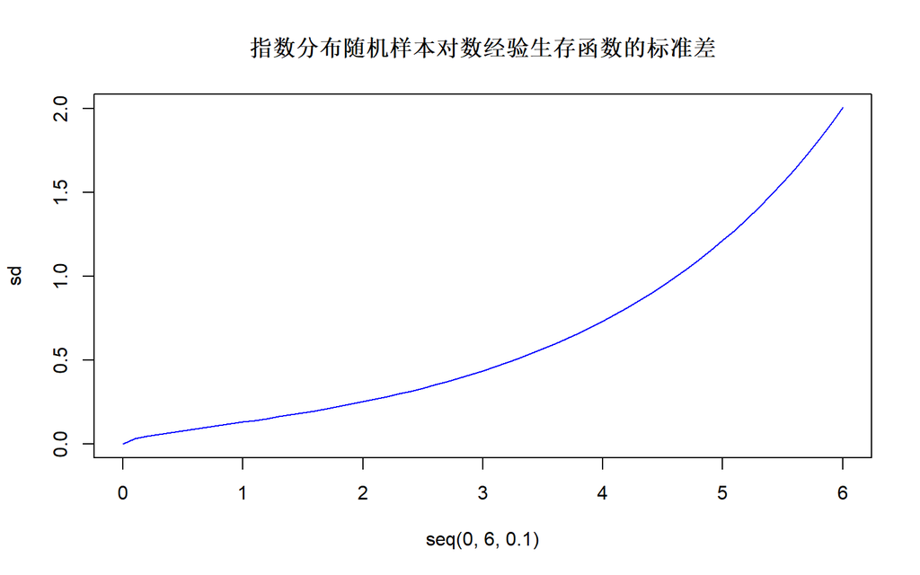

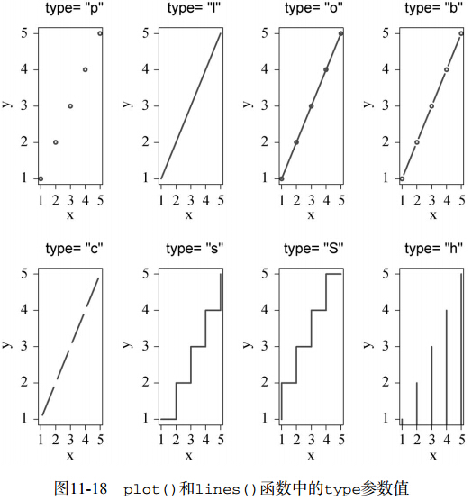

type of plot.

```r
size = 100
# 根据计算公式，直接算出对数经验生存函数的方差
var = pexp(seq(0, 6, 0.1), 1) / (1 - pexp(seq(0, 6, 0.1), 1)) / size
# 计算标准差
sd = sqrt(var)

# 画图
plot(seq(0, 6, 0.1),
     sd,
     type = 'l',
     col = 'blue',
     main = '指数分布随机样本对数经验生存函数的标准差')
```

其他重要参数`lty`线种类,’lwd’线宽度,’pch’点的类型

下面是对经验分布、经验生存、对数经验生存的基本可视化。

```r
size = 100
data = rexp(size, 1)
data.sort = sort(data)
data.rank = rank(data.sort)
data.cdf = data.rank / length(data)

# cdf cumulative distribution function 累积分布函数
# pdf probability density function 概率密度函数
# pmf probability mass function 概率质量函数,离散随机变量在各个特定取值上的概率
```

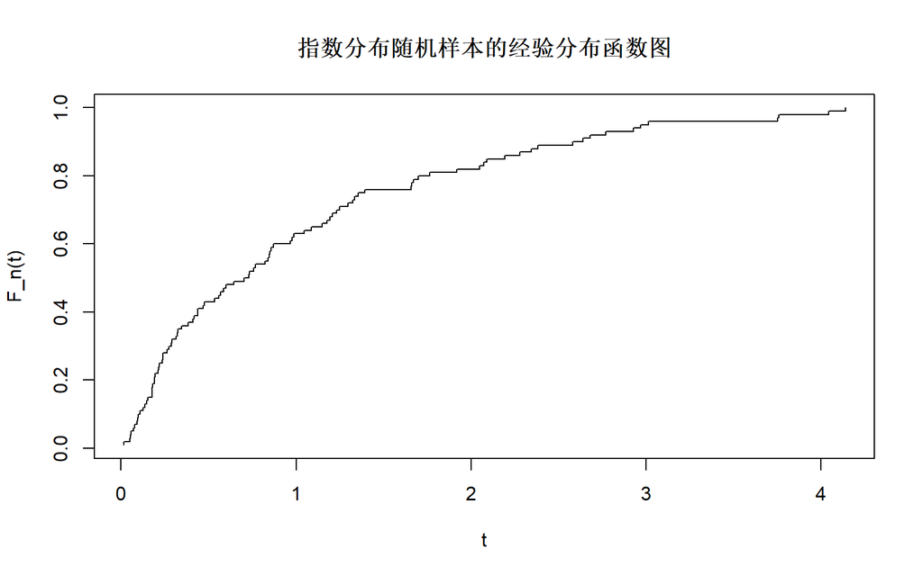

```r
# 经验分布
plot(data.sort, data.cdf, type = 's', main = '指数分布随机样本的经验分布函数图', xlab = 't', ylab = 'F_n(t)')
```

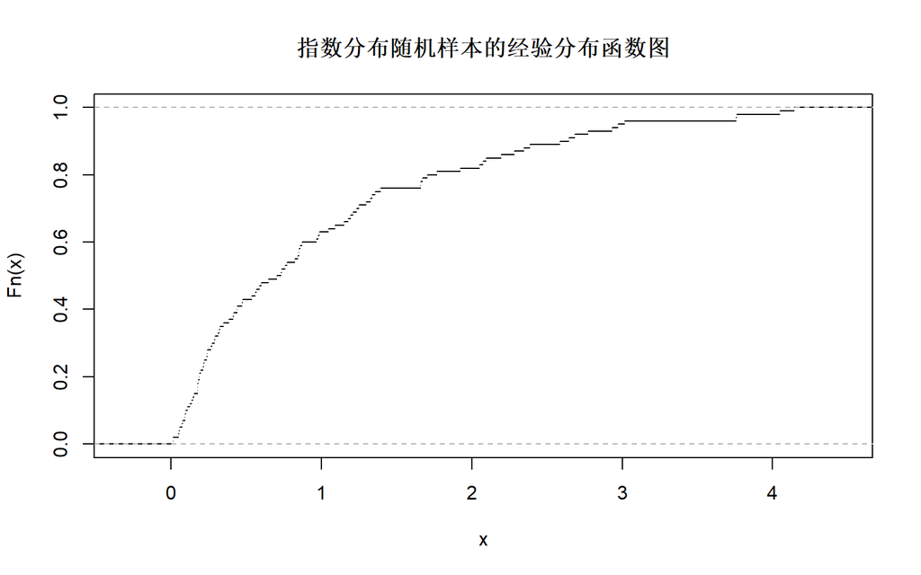

```r
#经验分布的另一种画法 plot.ecdf  do.points控制是否描点 verticals控制竖线 pch控制描点的类型
plot.ecdf(data, do.points = FALSE, verticals = FALSE, main = '指数分布随机样本的经验分布函数图')
```

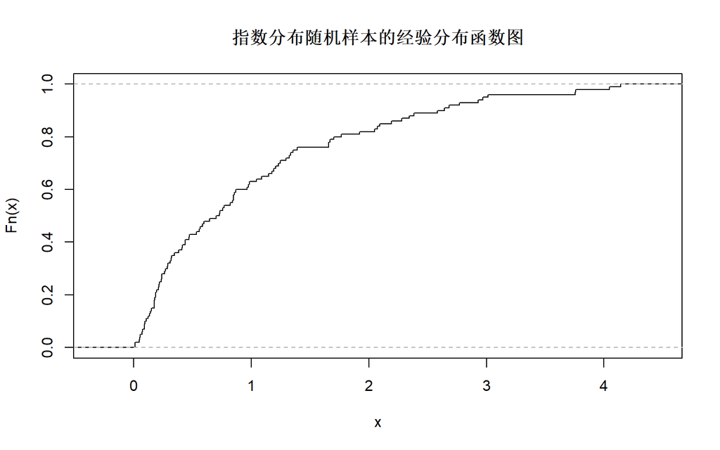

```r
plot.ecdf(data, do.points = FALSE, verticals = TRUE, main = '指数分布随机样本的经验分布函数图')
```

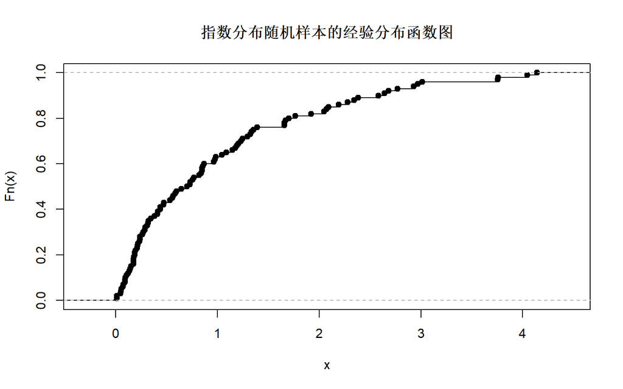

```r
plot.ecdf(data, do.points = TRUE, verticals = TRUE, main = '指数分布随机样本的经验分布函数图', pch = 19)
```

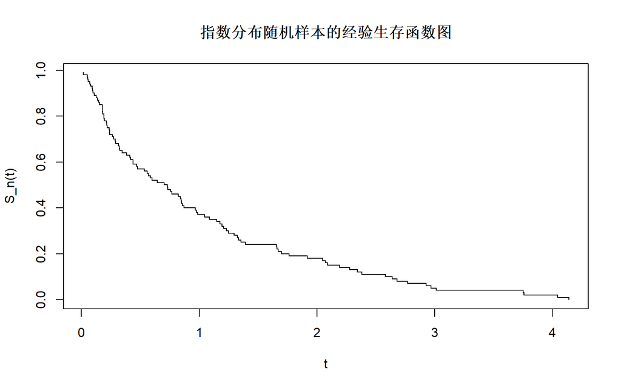

```r
# 经验生存
plot(data.sort, 1 - data.cdf, type = 's', main = '指数分布随机样本的经验生存函数图', xlab = 't', ylab = 'S_n(t)')
```

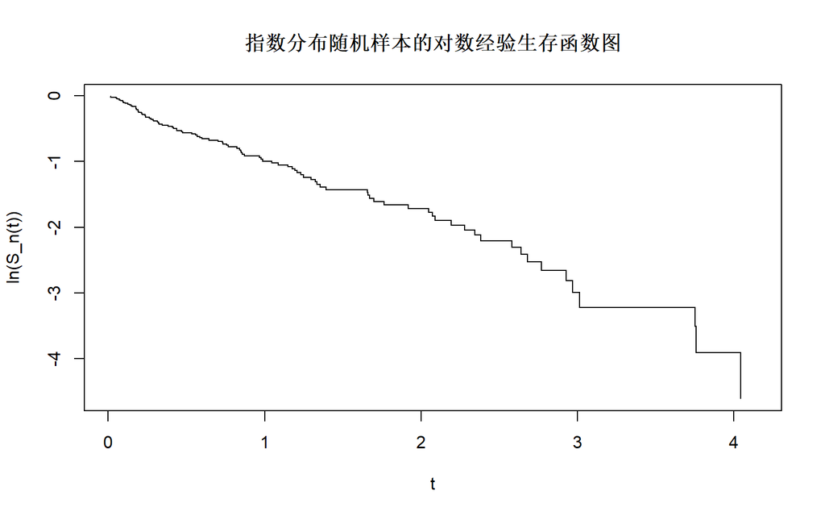

```r
# 对数经验生存
plot(data.sort, log(1 - data.cdf), type = 's', main = '指数分布随机样本的对数经验生存函数图', xlab = 't', ylab = 'ln(S_n(t))')
```

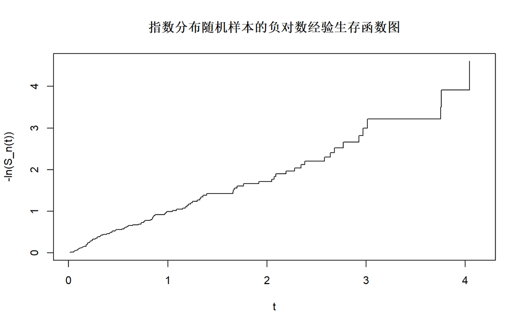

```r
# 负对数经验生存
plot(data.sort, -log(1 - data.cdf), type = 's', main = '指数分布随机样本的负对数经验生存函数图', xlab = 't', ylab = '-ln(S_n(t))')
```

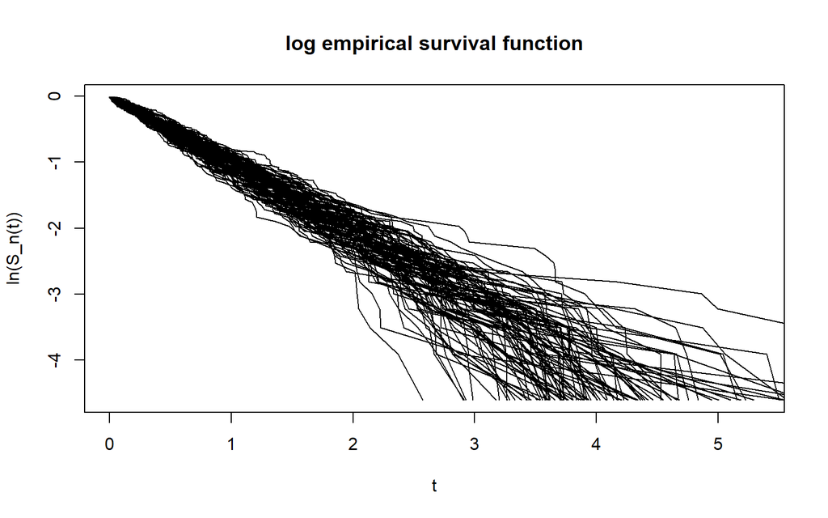

```r
# 编写函数simulate画groups条，样本量为size的对数经验生存函数
simulate = function(groups, size){
  set.seed(1024)
  data = rexp(size, 1)
  data.sort = sort(data)
  data.rank = rank(data.sort)
  data.cdf = data.rank / length(data)
  plot(data.sort, log(1 - data.cdf), type = 'l', lty = 1, main = 'log empirical survival function', xlab = 't', ylab = 'ln(S_n(t))')

  for(i in 2:groups){
    set.seed(7*i) # 固定随机数种子
    data = rexp(size, 1)
    data.sort = sort(data)
    data.rank = rank(data.sort)
    data.cdf = data.rank / length(data)
    lines(data.sort, log(1 - data.cdf), type = 'l', lty = 1)
  }
}

# 样本量100，画100组实验
simulate(100, 100)
```

很明显，经验生存函数的标准差，方差随着时间增加单调增大。这和(1)中直接计算得到的答案是吻合的。

## 1.12

考虑一个实验：对减轻皮肤瘙痒的药物进行疗效研究(Beecher,1959)。在10名20-30岁的男性志愿者身上做实验比较`五种药物`和`安慰剂`、`无药`的效果。

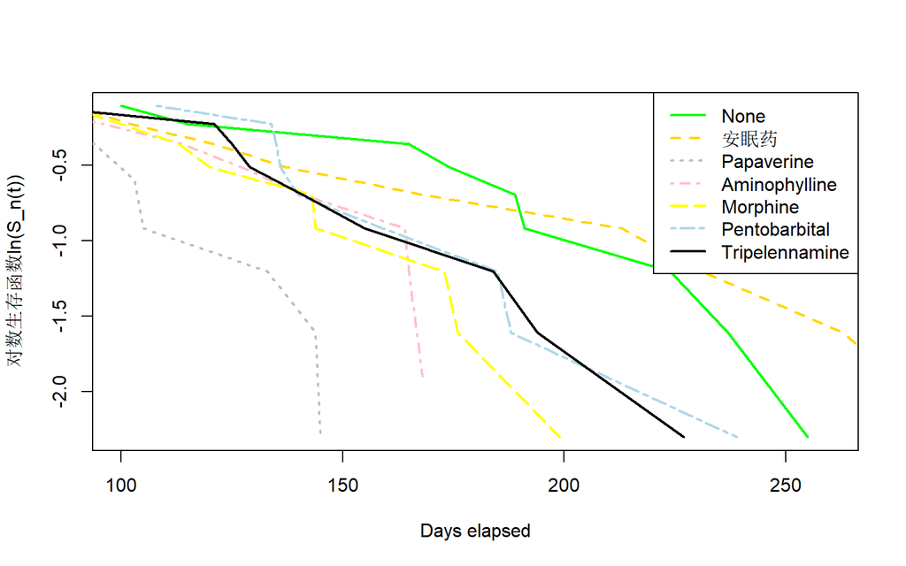

```r
# 数据加载
skin_data = read.csv('E:\\大三上\\Non-Parametric Statistics 王星\\1125share\\skin.csv', header = TRUE)

# 绘制各组的对数经验生存函数(瘙痒的生存)
plot(sort(skin_data$无药), log(1 - rank(sort(skin_data$无药)) / nrow(skin_data)),
     type = 'l', lty = 1, lwd = 2, col = 'green', xlab = "Days elapsed", ylab = "对数生存函数ln(S_n(t))")

lines(sort(skin_data$安慰剂), log(1 - rank(sort(skin_data$安慰剂)) / nrow(skin_data)),
      type = 'l', lty = 2, lwd = 2, col = 'gold')

lines(sort(skin_data$Papaverine), log(1 - rank(sort(skin_data$Papaverine)) / nrow(skin_data)),
      type = 'l', lty = 3, lwd = 2, col = 'grey')

lines(sort(skin_data$Aminophylline), log(1 - rank(sort(skin_data$Aminophylline)) / nrow(skin_data)),
      type = 'l', lty = 4, lwd = 2, col = 'pink')

lines(sort(skin_data$Morphine), log(1 - rank(sort(skin_data$Morphine)) / nrow(skin_data)),
      type = 'l', lty = 5, lwd = 2, col = 'yellow')

lines(sort(skin_data$Pentobarbital), log(1 - rank(sort(skin_data$Pentobarbital)) / nrow(skin_data)),
      type = 'l', lty = 6, lwd = 2, col = 'lightblue')

lines(sort(skin_data$Tripelennamine), log(1 - rank(sort(skin_data$Tripelennamine)) / nrow(skin_data)),
      type = 'l', lty = 7, lwd = 2, col = 'black')

legend("topright", lty = 1:7, lwd = rep(2, 7),
       legend = c("None", "安眠药", "Papaverine", "Aminophylline", "Morphine", "Pentobarbital", "Tripelennamine"),
       col = c('green', 'gold', 'grey', 'pink', 'yellow', 'lightblue', 'black'))
```

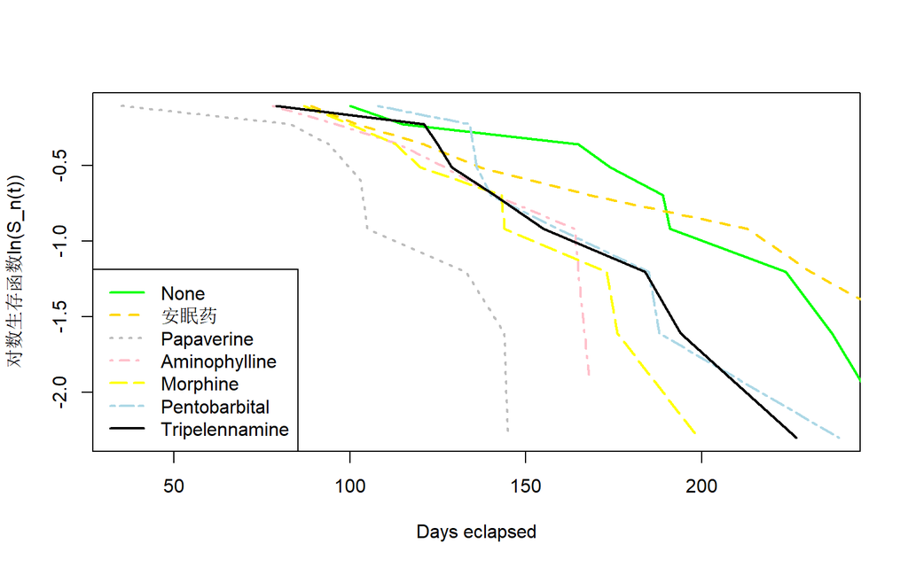

```r
# 调整一下画图的先后顺序可以让所有线的开头都画出来
plot(sort(skin_data$Papaverine), log(1 - rank(sort(skin_data$Papaverine)) / nrow(skin_data)),
     type = 'l', lty = 3, lwd = 2, col = 'grey', xlab = "Days eclapsed", ylab = "对数生存函数ln(S_n(t))")

lines(sort(skin_data$无药), log(1 - rank(sort(skin_data$无药)) / nrow(skin_data)),
      type = 'l', lty = 1, lwd = 2, col = 'green', xlab = "days", ylab = "ln(S_n(t))")

lines(sort(skin_data$安慰剂), log(1 - rank(sort(skin_data$安慰剂)) / nrow(skin_data)),
      type = 'l', lty = 2, lwd = 2, col = 'gold')

lines(sort(skin_data$Aminophylline), log(1 - rank(sort(skin_data$Aminophylline)) / nrow(skin_data)),
      type = 'l', lty = 4, lwd = 2, col = 'pink')

lines(sort(skin_data$Morphine), log(1 - rank(sort(skin_data$Morphine)) / nrow(skin_data)),
      type = 'l', lty = 5, lwd = 2, col = 'yellow')

lines(sort(skin_data$Pentobarbital), log(1 - rank(sort(skin_data$Pentobarbital)) / nrow(skin_data)),
      type = 'l', lty = 6, lwd = 2, col = 'lightblue')

lines(sort(skin_data$Tripelennamine), log(1 - rank(sort(skin_data$Tripelennamine)) / nrow(skin_data)),
      type = 'l', lty = 7, lwd = 2, col = 'black')

legend("bottomleft", lty = 1:7, lwd = rep(2, 7),
       legend = c("None", "安眠药", "Papaverine", "Aminophylline", "Morphine", "Pentobarbital", "Tripelennamine"),
       col = c('green', 'gold', 'grey', 'pink', 'yellow', 'lightblue', 'black'))
```

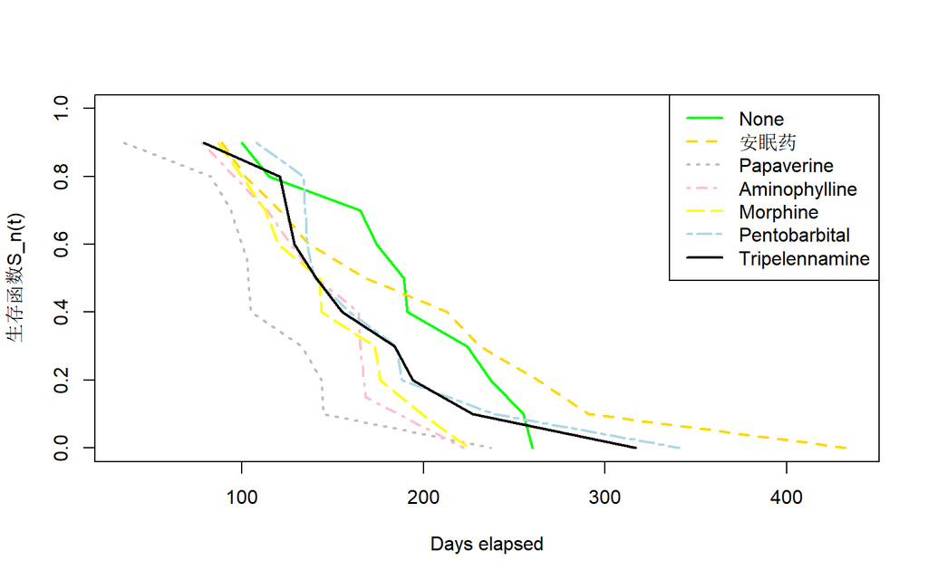

```r
## 经验生存函数
plot(sort(skin_data$无药), (1 - rank(sort(skin_data$无药)) / nrow(skin_data)),
     type = 'l', lty = 1, lwd = 2, col = 'green',
     xlim = c(35, 435), ylim = c(0,1),
     xlab = "Days elapsed", ylab = "生存函数S_n(t)")

lines(sort(skin_data$安慰剂), (1 - rank(sort(skin_data$安慰剂)) / nrow(skin_data)),
      type = 'l', lty = 2, lwd = 2, col = 'gold')

lines(sort(skin_data$Papaverine), (1 - rank(sort(skin_data$Papaverine)) / nrow(skin_data)),
      type = 'l', lty = 3, lwd = 2, col = 'grey')

lines(sort(skin_data$Aminophylline), (1 - rank(sort(skin_data$Aminophylline)) / nrow(skin_data)),
      type = 'l', lty = 4, lwd = 2, col = 'pink')

lines(sort(skin_data$Morphine), (1 - rank(sort(skin_data$Morphine)) / nrow(skin_data)),
      type = 'l', lty = 5, lwd = 2, col = 'yellow')

lines(sort(skin_data$Pentobarbital), (1 - rank(sort(skin_data$Pentobarbital)) / nrow(skin_data)),
      type = 'l', lty = 6, lwd = 2, col = 'lightblue')

lines(sort(skin_data$Tripelennamine), (1 - rank(sort(skin_data$Tripelennamine)) / nrow(skin_data)),
      type = 'l', lty = 7, lwd = 2, col = 'black')

legend("topright", lty = 1:7, lwd = rep(2, 7),
       legend = c("None", "安眠药", "Papaverine", "Aminophylline", "Morphine", "Pentobarbital", "Tripelennamine"),
       col = c('green', 'gold', 'grey', 'pink', 'yellow', 'lightblue', 'black'))
```

**备注** 旧书P15例1.5画的图取了负号

# 思考题

## 一、分布函数

思考什么变量的分布函数满足经验分布
$$\hat F_n(x) = \frac{1}{n}\sum_{i=1}^n I(x_i \leqslant x)$$
设离散型随机变量y, $y \in\{x_1,x_2,...x_n\}$ 且 $P\{y=x_i\}=\frac{1}{n},i=1,2,...,n$ 其有分布函数
$$F(x)=\left\{
\begin{array}{1}
\begin{aligned}
1 &,& x\geqslant x_{(n)} \\
\frac{i}{n} &,& x_{(i)} \leqslant x < x_{(i+1)}\\
0 &,& x < x_{(1)}
\end{aligned}
\end{array}
\right.$$
与$\hat F_n(x)$的一致。

## 二、Neyman-Pearson

讨论引理中$f=f_0$的情况

根据定义，两个拒绝域$W_\alpha, W'\in X$一个尺度为$\alpha$，另一个水平为$\alpha$，即满足$P\{x\in W_\alpha\}=\alpha, P\{x\in W'\}\leqslant\alpha,$

事实上，$\int_{W_\alpha} f_0(x)dx=P\{x\in W_\alpha | \theta \in \theta_0\}=\alpha$

并且，$\int_{W'} f_0(x)dx=P\{x\in W' | \theta \in \theta_0\}\leqslant \alpha$

自然得到了 $\int_{W_\alpha} f_0(x)dx \geqslant \int_{W'} f_0(x)dx$